# All vs ORD for Channels 13 and 21

Lia Ossanna

2/2/2022

# Introduction

- Channels 13 and 21 have both baffles and one rock dams (ORDs). Unlike ORDs, baffles are meant to increase sinuosity by eroding the side of the channel opposite to the baffle. ORDs are meant to catch sediment and increase vegetation cover.
- Because of this distinction, I looked at the difference between including all stations in analysis for Channels 13 and 21 (baffle and ORD stations), versus ORD only.
- I ran statistics (comparison of means) for total plant cover, soil cover, and herbaceous cover, using ANOVA with post-hoc Tukey for normally distributed comparisons, and Kruskal-Wallis with post-hoc Dunn for non-normally distributed comparisons.

# Summary

# Total plant cover

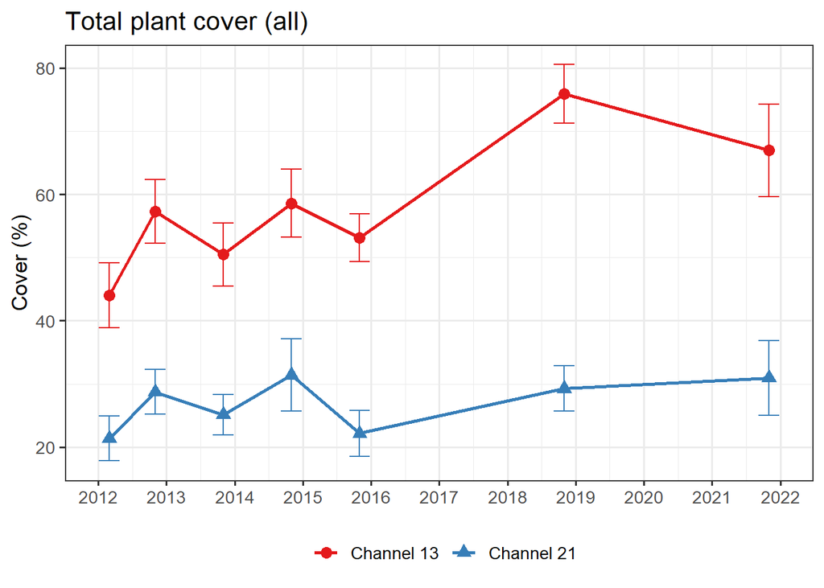

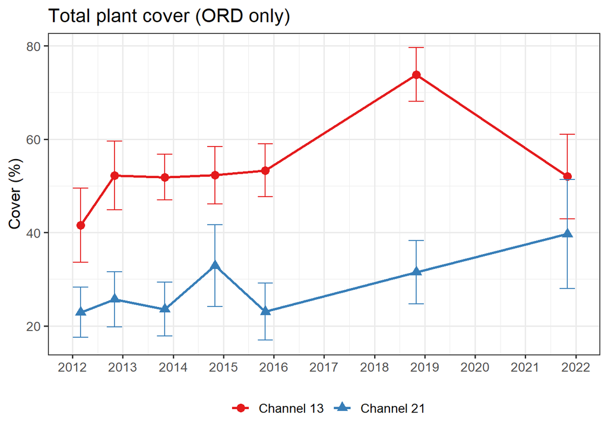

## Stats

### All

- Channels 13 & 21 were not normally distributed.
- Channel 21 had no significant differences over time.

```
## # A tibble: 6 x 4
## # Groups:   Channel, Year [6]
##   Channel    Year   mean groups
##   <chr>      <chr> <dbl> <chr>
## 1 Channel 13 2018   75.9 a
## 2 Channel 13 2021   67.0 ab
## 3 Channel 13 2014   58.6 ab
## 4 Channel 13 2012   57.3 ab
## 5 Channel 13 2015   53.1 b
## 6 Channel 13 2013   50.5 b
```

### ORD only

- Channels 13 & 21 were normally distributed.
- Neither had significant differences over time.

### Comparison

- Using all stations, Channel 13 was not normally distributed and had significant changes.
- Using only ORD stations, Channel 13 was normally distributed and had no significant changes.

# Soil cover

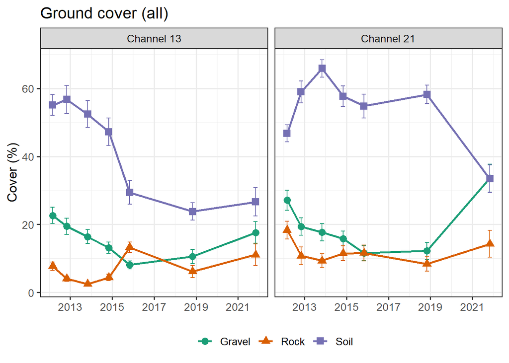

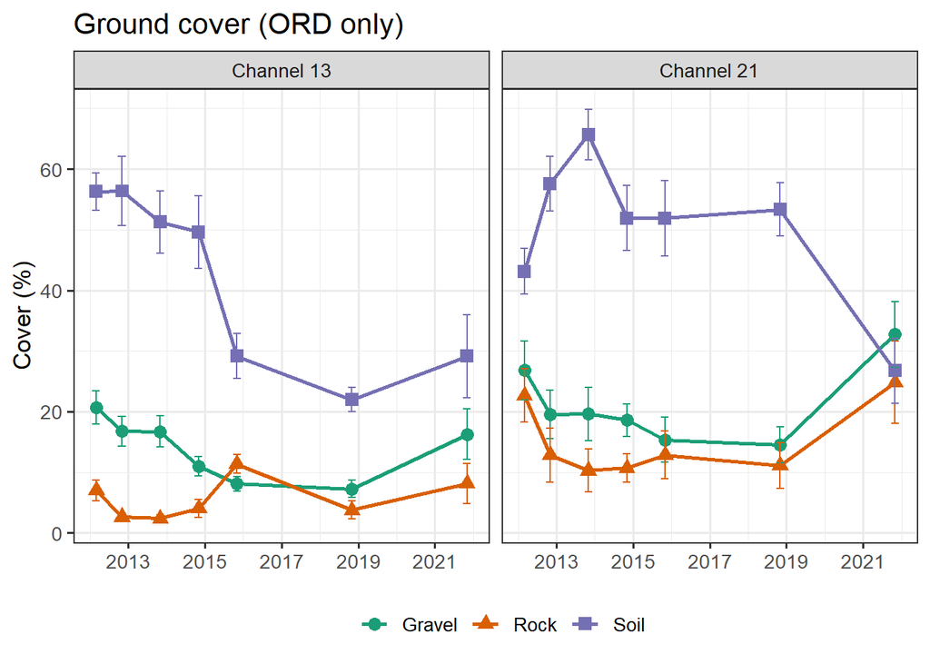

## Stats

### All

- Channel 13 was normally distributed, while Channel 21 was not.

```
##      soil13$Cover groups
## 2012     56.76042      a
## 2013     52.47024      a
## 2014     47.26562      a
## 2015     29.42188      b
## 2021     26.63214      b
## 2018     23.82031      b
```

```
## # A tibble: 6 x 4
## # Groups:   Channel, Year [6]
##   Channel    Year   mean groups
##   <chr>      <chr> <dbl> <chr>
## 1 Channel 21 2013   65.9 a
## 2 Channel 21 2012   59.0 a
## 3 Channel 21 2018   58.3 a
## 4 Channel 21 2014   57.7 a
## 5 Channel 21 2015   54.8 a
## 6 Channel 21 2021   33.4 b
```

### ORD only

- Channels 13 and 21 were normally distributed.

```
##            soil.ord13$Cover groups
## 2012-11-01         56.36111      a
## 2013-11-01         51.25000      a
## 2014-11-01         49.58333      a
## 2015-11-01         29.16667      b
## 2021-11-01         29.13929      b
## 2018-11-01         21.97222      b
```

```
##            soil.ord21$Cover groups
## 2013-11-01         65.69444      a
## 2012-11-01         57.56944      a
## 2018-11-01         53.33333      a
## 2014-11-01         51.87500      a
## 2015-11-01         51.87500      a
## 2021-11-01         26.77083      b
```

### Comparison

- Using all stations, Channel 21 was not normally distributed, while using ORD stations only, Channel 21 was normally distributed.
- Channel 13 was normally distributed using all stations and ORD only stations.
- The letters were the same for both Channel 13 and 21.

# Herbaceous cover

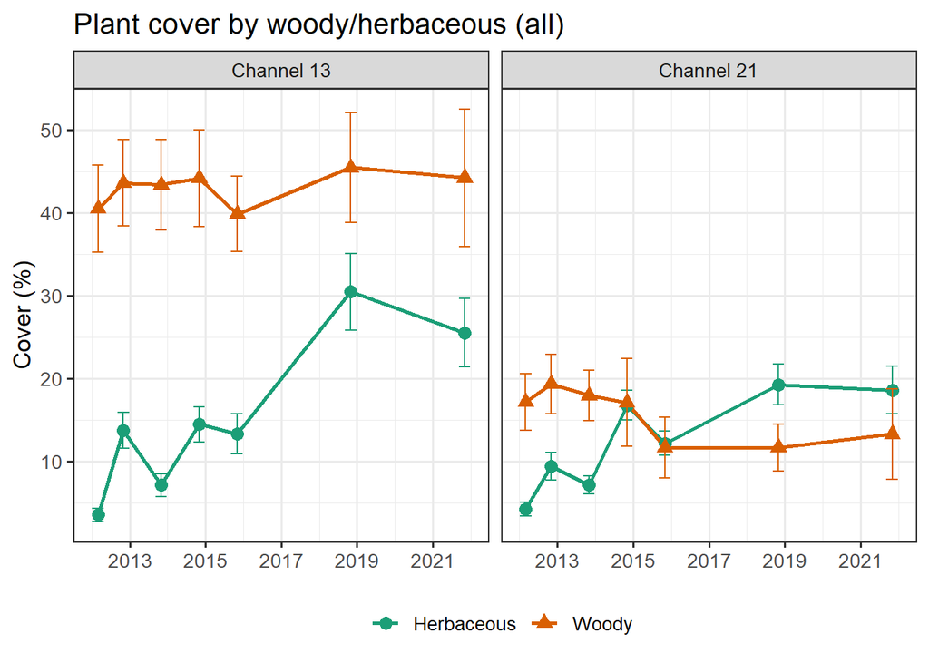

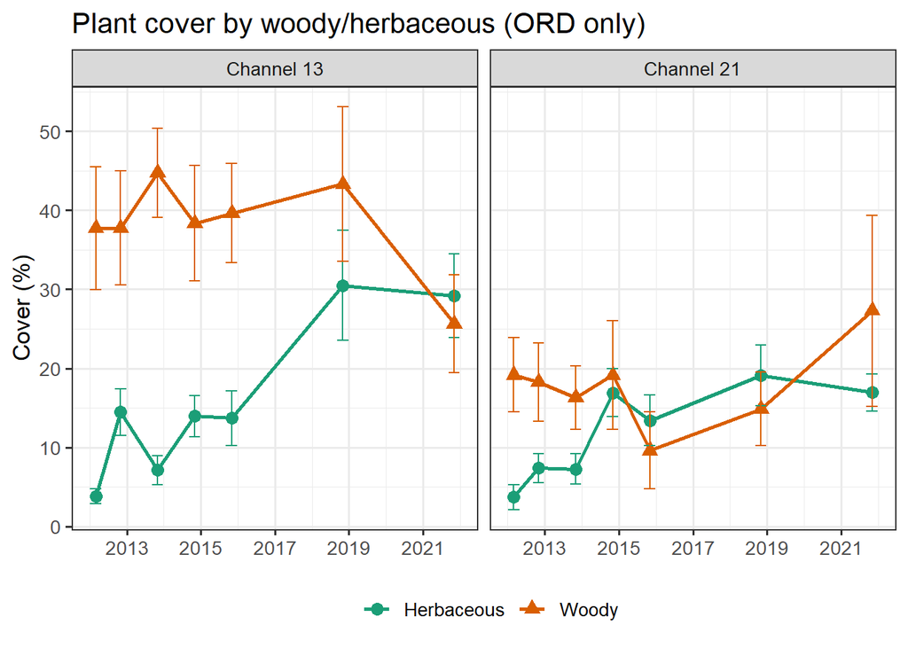

## Stats

### All

- Channel 13 was not normally distributed; Channel 21 was normally distributed.

```
## # A tibble: 6 x 4
## # Groups:   Channel, Year [6]
##   Channel    Year   mean groups
##   <chr>      <chr> <dbl> <chr>
## 1 Channel 13 2018  30.4  a
## 2 Channel 13 2021  25.5  ab
## 3 Channel 13 2014  14.4  abc
## 4 Channel 13 2012  13.7  abc
## 5 Channel 13 2015  13.3  bc
## 6 Channel 13 2013   7.12 c
```

```
##      herb21$Cover groups
## 2018    19.267857      a
## 2021    18.589286      a
## 2014    16.754464     ab
## 2015    12.187500    abc
## 2012     9.404762     bc
## 2013     7.175595      c
```

### ORD only

- Channel 13 was not normally distributed; Channel 21 was normally distributed.

```
## # A tibble: 6 x 4
## # Groups:   Channel, Year [6]
##   Channel    Year   mean groups
##   <chr>      <chr> <dbl> <chr>
## 1 Channel 13 2018  30.5  a
## 2 Channel 13 2021  29.2  a
## 3 Channel 13 2012  14.5  ab
## 4 Channel 13 2014  14.0  ab
## 5 Channel 13 2015  13.7  ab
## 6 Channel 13 2013   7.13 b
```

```
##      herb.ord21$Cover groups
## 2018        19.083333      a
## 2021        16.937500      a
## 2014        16.927083      a
## 2015        13.416667      a
## 2012         7.402778      a
## 2013         7.284722      a
```

### Comparison

- Distributions were the same for all stations and ORD only.
- Letters for both channels were slightly different. Unsure why Channel 21 ORD only are all assigned group a.